# Recomendador de Filmes

Movie Recommender: Collaborative Filtering, Shiny - IMDB - Internet Movie DataBases

Ewerson C. Pimenta

pimentaeu@yahoo.com

Marcos Antônio E. de Oliveira

marcoseuzbio@gmail.com

Rio de Janeiro, 03 de outubro de 2018

# 1 Introdução

Frequentemente utilizamos serviços de recomendação seja por plataformas como *Netflix, Mercado Livre, OLX* dentre outros. O conjunto de dados explanados a seguir foram extraídos da plataforma Kaggle e são referentes ao catálogo de filmes da plataforma IMDB, o intuito aqui é criar um sistema de recomendação orientado a dados do catálogo e avaliação de filmes do IMDB.

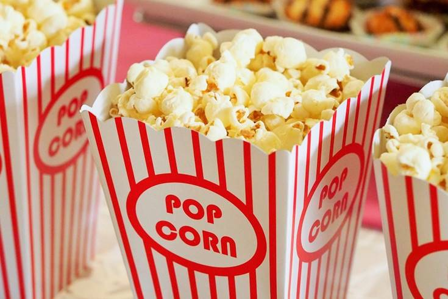

**Pacotes e Leitura**

Alguns pacotes R utilizados nessa rotina

```yaml
library(tidyverse)          # Manipulação de banco de dados e análise exploratória
library(highcharter)        # Highchart gráficos usando htmlwidgets (renderiza HTML via código R Markdown)
library(DT)                 # Tabelas: datatable()
library(knitr)
library(kableExtra)
library(rpart.plot)
library(randomForest)
```

```yaml
RECOMEND.METADATA = readxl::read_xlsx(path = ".../DB/IMDB.xlsx", sheet = 1)
db = RECOMEND.METADATA
```

> Parte I

# 2 Banco de Dados

|  | Variables | Description |
| --- | --- | --- |
| 1 | movie_title | Title of the Movie |
| 2 | duration | Duration in minutes |
| 3 | director_name | Name of the Director of the Movie |
| 4 | director_facebook_likes | Number of likes of the Director on his Facebook Page |
| 5 | actor_1_name | Primary actor starring in the movie |
| 6 | actor_1_facebook_likes | Number of likes of the Actor_1 on his/her Facebook Page |
| 7 | actor_2_name | Other actor starring in the movie |
| 8 | actor_2_facebook_likes | Number of likes of the Actor_2 on his/her Facebook Page |
| 9 | actor_3_name | Other actor starring in the movie |
| 10 | actor_3_facebook_likes | Number of likes of the Actor_3 on his/her Facebook Page |

[output cut: 18 more lines]

*Os dados em questão são públicos e disponíveis para download clicando [AQUI](https://data.world/data-society/imdb-5000-movie-dataset) ou [AQUI](https://www.kaggle.com/carolzhangdc/analyze-imdb-score-with-data-mining-algorithms/data).*

# 3 Análise Exploratória dos dados

```r
set.seed(123465)
amostra1 = sample(x = 1:dim(db)[1], size = 35, replace = FALSE)
t1 = as.data.frame(db[amostra1,]); rownames(t1) = as.character(amostra1)
datatable(db[amostra1,],  rownames = amostra1,
          options = list(searchin = TRUE, scrollX = TRUE, pageLength = 5))
```

| color | director_name | num_critic_for_reviews | duration | director_facebook_likes | actor_3_facebook_likes | actor_2_name | actor_1_facebook_likes | gross | genres | actor_1_name | movie_title | num_voted_users | cast_total_facebook_likes | actor_3_name | facenumber_in_poster | plot_keywords | movie_imdb_link | num_user_for_reviews | language | country | content_rating | budget | title_year | actor_2_facebook_likes | imdb_score | aspect_ratio | movie_facebook_likes |
| --- | --- | --- | --- | --- | --- | --- | --- | --- | --- | --- | --- | --- | --- | --- | --- | --- | --- | --- | --- | --- | --- | --- | --- | --- | --- | --- | --- |
| Color | Jem Cohen | 12 | 111 | 6 |  |  |  |  | Documentary |  | CountingÂ | 61 | 0 |  | 0 | city\|city symphony\|diary\|essay\|surveillance | http://www.imdb.com/title/tt4462082/?ref_=fn_tt_tt_1 | 1 | English | USA |  | 50000 | 2015 |  | 6.0 | 1.78 | 5 |
| Color | Paul Schrader | 75 | 106 | 261 | 520 | Ayelet Zurer | 30000 |  | Drama\|War | Veronica Ferres | Adam ResurrectedÂ | 3075 | 31325 | Derek Jacobi | 2 | circus\|dog\|entertainer\|holocaust\|patient | http://www.imdb.com/title/tt0479341/?ref_=fn_tt_tt_1 | 31 | English | Germany | R | 10000000 | 2008 | 744 | 6.3 | 2.35 | 589 |
| Color | Frederik Du Chau | 73 | 102 | 7 | 521 | Frankie Muniz | 984 | 49186871 | Adventure\|Comedy\|Drama\|Family\|Sport | Bruce Greenwood | Racing StripesÂ | 12570 | 2910 | M. Emmet Walsh | 0 | farm\|horse\|kentucky\|racehorse\|zebra | http://www.imdb.com/title/tt0376105/?ref_=fn_tt_tt_1 | 86 | English | USA | PG |  | 2005 | 934 | 5.2 | 1.85 | 771 |
| Color | Robert Luketic | 174 | 96 | 126 | 954 | John Michael Higgins | 18000 | 88915214 | Comedy\|Romance | Gerard Butler | The Ugly TruthÂ | 163665 | 22436 | Eric Winter | 2 | call in\|chick flick\|date\|hot air balloon\|show producer | http://www.imdb.com/title/tt1142988/?ref_=fn_tt_tt_1 | 169 | English | USA | R | 38000000 | 2009 | 957 | 6.5 | 2.35 | 9000 |
| Color |  | 4 | 60 |  | 398 | Brittany Curran | 629 |  | Drama\|Mystery\|Thriller | Grey Damon | TwistedÂ | 7945 | 2758 | Aaron Hill | 2 |  | http://www.imdb.com/title/tt2355844/?ref_=fn_tt_tt_1 | 22 | English | USA |  |  |  | 512 | 7.5 | 16.0 | 915 |
| Color | Annabel Jankel | 36 | 104 | 5 | 687 | Fisher Stevens | 5000 | 20915465 | Adventure\|Comedy\|Family\|Fantasy\|Sci-Fi | Bob Hoskins | Super Mario Bros.Â | 38203 | 7723 | Fiona Shaw | 0 | based on video game\|dinosaur\|king\|mario\|plumber | http://www.imdb.com/title/tt0108255/?ref_=fn_tt_tt_1 | 290 | English | UK | PG | 42000000 | 1993 | 922 | 4.0 | 1.85 | 0 |
| Color | Dennis Dugan | 179 | 102 | 221 | 4000 | Adam Sandler | 12000 | 162001186 | Comedy | Steve Buscemi | Grown UpsÂ | 181443 | 28497 | Salma Hayek | 4 | basketball\|coach\|daughter\|high school\|high school basketball | http://www.imdb.com/title/tt1375670/?ref_=fn_tt_tt_1 | 311 | English | USA | PG-13 | 80000000 | 2010 | 11000 | 6.0 | 1.85 | 12000 |
| Color | Nelson McCormick | 146 | 89 | 29 | 458 | Scott Porter | 2000 | 43818159 | Horror\|Mystery | Ming-Na Wen | Prom NightÂ | 27664 | 4867 | Collins Pennie | 0 | friend\|hotel\|killer\|murder\|prom | http://www.imdb.com/title/tt0926129/?ref_=fn_tt_tt_1 | 260 | English | USA | PG-13 | 20000000 | 2008 | 690 | 3.9 | 2.35 | 1000 |
| Color | Robert Stevenson | 145 | 139 | 55 | 266 | Glynis Johns | 382 | 102300000 | Comedy\|Family\|Fantasy\|Musical | Ed Wynn | Mary PoppinsÂ | 107408 | 2045 | Elsa Lanchester | 2 | banker\|female protagonist\|live action and animation\|magic\|nanny | http://www.imdb.com/title/tt0058331/?ref_=fn_tt_tt_1 | 259 | English | USA | Approved | 6000000 | 1964 | 279 | 7.8 | 1.66 | 0 |
| Color | Niki Caro | 149 | 101 | 51 | 8 | Rawiri Paratene | 446 | 20772796 | Drama\|Family | Keisha Castle-Hughes | Whale RiderÂ | 34232 | 497 | Tammy Davis | 1 | girl\|maori\|new zealand\|tradition\|whale | http://www.imdb.com/title/tt0298228/?ref_=fn_tt_tt_1 | 346 | English | New Zealand | PG-13 | 6000000 | 2002 | 20 | 7.6 | 2.35 | 0 |

[output cut: 25 more lines]

## 3.1 Estrutura dos dados

```
## O banco de dados possui 5043 observações e 28 variáveis
```

Excluindo algumas variáveis que não serão utilizadas.

```r
db = db %>% select(- director_facebook_likes, -actor_3_facebook_likes, -actor_2_name, -actor_1_facebook_likes, -actor_1_name, -actor_3_name,-facenumber_in_poster, -actor_2_facebook_likes)
```

```
## O banco de dados agora possui 20 variáveis
```

Estrutura dos dados

```r
glimpse(db) #str(db)
```

```
## Observations: 5,043
## Variables: 20
## $ color                     <chr> "Color", "Color", "Color", "Color", ...
## $ director_name             <chr> "James Cameron", "Gore Verbinski", "...
## $ num_critic_for_reviews    <dbl> 723, 302, 602, 813, NA, 462, 392, 32...
## $ duration                  <dbl> 178, 169, 148, 164, NA, 132, 156, 10...
## $ gross                     <dbl> 760505847, 309404152, 200074175, 448...
## $ genres                    <chr> "Action|Adventure|Fantasy|Sci-Fi", "...
## $ movie_title               <chr> "AvatarÂ ", "Pirates of the Caribbea...
## $ num_voted_users           <dbl> 886204, 471220, 275868, 1144337, 8, ...
## $ cast_total_facebook_likes <dbl> 4834, 48350, 11700, 106759, 143, 187...
## $ plot_keywords             <chr> "avatar|future|marine|native|paraple...
## $ movie_imdb_link           <chr> "http://www.imdb.com/title/tt0499549...
## $ num_user_for_reviews      <dbl> 3054, 1238, 994, 2701, NA, 738, 1902...
## $ language                  <chr> "English", "English", "English", "En...
## $ country                   <chr> "USA", "USA", "UK", "USA", NA, "USA"...
## $ content_rating            <chr> "PG-13", "PG-13", "PG-13", "PG-13", ...
## $ budget                    <dbl> 237000000, 300000000, 245000000, 250...
## $ title_year                <dbl> 2009, 2007, 2015, 2012, NA, 2012, 20...
## $ imdb_score                <chr> "7.9", "7.1", "6.8", "8.5", "7.1", "...
## $ aspect_ratio              <chr> "1.78", "2.35", "2.35", "2.35", NA, ...
## $ movie_facebook_likes      <dbl> 33000, 0, 85000, 164000, 0, 24000, 0...
```

## 3.2 Tratamento de NA

Porcentagem de NA por variável

```r
db_miss <- db %>% summarise_all(funs(sum(is.na(.))/n()))
db_miss <- gather(db_miss, key = "variables", value = "percent_missing")
db_miss$percent_missing = 100*db_miss$percent_missing
db_miss = db_miss[order(db_miss$percent_missing, decreasing = TRUE), ]
#db_miss

hc <- highchart() %>%
  hc_add_series(data = db_miss$percent_missing,
                type = "bar",
                name = "Porcentagem de missing",
                showInLegend = FALSE,
                tooltip = list(valueDecimals = 2, valuePrefix = "", valueSuffix = " %")) %>%
  hc_yAxis(title = list(text = "Porcentagem de missing"),
           allowDecimals = TRUE, max = 20,
           labels = list(format = "{value}%")) %>%
  hc_xAxis(categories = db_miss$variables,
           tickmarkPlacement = "on",
           opposite = FALSE) %>%
  hc_title(text = "Porcentagem de missinig por variável",
           style = list(fontWeight = "bold")) %>%
  hc_subtitle(text = paste("")) %>%
      hc_tooltip(valueDecimals = 2,
                 pointFormat = "Missing: {point.y}")%>%
                 #pointFormat = "Variável: {point.x} <br> Missing: {point.y}")
      hc_credits(enabled = TRUE,
                 text = "Fonte: IMDB/KAGGLE. Elaboração: Ewerson Pimenta.",
                 style = list(fontSize = "10px")) %>%
  hc_exporting(enabled = TRUE, filename = "F1-missing-Pimenta")
#hc <- hc %>%
#  hc_add_theme(hc_theme_darkunica())
hc
```

[interactive chart not shown]

Removendo todas as observações que contêm NA.

```r
#db1 <- db %>% na.omit()
#db1 <- db %>% drop_na()

db1 <- db %>% drop_na(gross, budget, aspect_ratio
,content_rating, plot_keywords, title_year
,director_name, num_critic_for_reviews, num_user_for_reviews
,color, duration, language
,country, num_voted_users, cast_total_facebook_likes
,movie_imdb_link, imdb_score, movie_facebook_likes)
glimpse(db1)
```

```
## Observations: 3,766
## Variables: 20
## $ color                     <chr> "Color", "Color", "Color", "Color", ...
## $ director_name             <chr> "James Cameron", "Gore Verbinski", "...
## $ num_critic_for_reviews    <dbl> 723, 302, 602, 813, 462, 392, 324, 6...
## $ duration                  <dbl> 178, 169, 148, 164, 132, 156, 100, 1...
## $ gross                     <dbl> 760505847, 309404152, 200074175, 448...
## $ genres                    <chr> "Action|Adventure|Fantasy|Sci-Fi", "...
## $ movie_title               <chr> "AvatarÂ ", "Pirates of the Caribbea...
## $ num_voted_users           <dbl> 886204, 471220, 275868, 1144337, 212...
## $ cast_total_facebook_likes <dbl> 4834, 48350, 11700, 106759, 1873, 46...
## $ plot_keywords             <chr> "avatar|future|marine|native|paraple...
## $ movie_imdb_link           <chr> "http://www.imdb.com/title/tt0499549...
## $ num_user_for_reviews      <dbl> 3054, 1238, 994, 2701, 738, 1902, 38...
## $ language                  <chr> "English", "English", "English", "En...
## $ country                   <chr> "USA", "USA", "UK", "USA", "USA", "U...
## $ content_rating            <chr> "PG-13", "PG-13", "PG-13", "PG-13", ...
## $ budget                    <dbl> 237000000, 300000000, 245000000, 250...
## $ title_year                <dbl> 2009, 2007, 2015, 2012, 2012, 2007, ...
## $ imdb_score                <chr> "7.9", "7.1", "6.8", "8.5", "6.6", "...
## $ aspect_ratio              <chr> "1.78", "2.35", "2.35", "2.35", "2.3...
## $ movie_facebook_likes      <dbl> 33000, 0, 85000, 164000, 24000, 0, 2...
```

```
## O novo banco de dados, sem observações faltantes, possui 3766 observações. Ou seja, no processo de remoção de valores faltantes foram perdidas 1277 observações.
```

## 3.3 Transformação de variáveis

Transformando as variáveis `imdb_score` e `aspect_ratio` em numéricas

```r
db$imdb_score = as.numeric(as.character(db$imdb_score))
db$aspect_ratio = as.numeric(as.character(db$aspect_ratio))
```

```r
hchart(db1$imdb_score, color = "#e8bb0b", name = "imdb_score") %>%
  hc_title(text = "Histograma dos votos na plataforma IMDB") %>%
  hc_exporting(enabled = TRUE, filename = "F2-Pimenta")
```

[interactive chart not shown]

```r
hchart(db1$num_voted_users, color = "#786eea", name = "imdb_num_votos") %>%
  hc_title(text = "Histograma dos número de votos na plataforma IMDB") %>%
  hc_exporting(enabled = TRUE, filename = "F3-Pimenta")
```

[interactive chart not shown]

Criando uma função para cálculo da moda

```r
Moda <- function(x) {
     ux <- unique(x)
     ux[which.max(tabulate(match(x, ux)))]
}
```

```
## Média, moda e mediana da variável imdb_score são, respectivamente, NA 6.7 NA
```

Extraindo valores da variável gênero e transformando em dummies

```r
gg <- as.character(db1$genres)

t <- unlist(strsplit(gg[1],split = "\\|"))
tem1 <- data.frame()
for(i in 1:length(gg)){
        tem <- tem1
        t <- unlist(strsplit(gg[i],split = "\\|"))
        temp <- data.frame(t)
        tem1 <- rbind(tem,temp)
}

Gen <- unique(tem1)
cat("Existem", dim(Gen)[1], "valores de gêneros de filme únicos no banco de dados.")
```

```
## Existem 22 valores de gêneros de filme únicos no banco de dados.
```

```r
Genname <- as.character(Gen$t)

fe <- matrix(data = 0, nrow = length(gg), ncol = length(Genname))
fe <- data.frame(fe); colnames(fe) <- Genname

for(i in 1:length(gg)){
        for(j in 1:length(Genname)){
                g <- grepl(Genname[j], gg[i])
                if(g == TRUE){
                        fe[i, j] <- 1
                }
        }
}

NumGen = as_tibble(rbind(apply(fe,2,sum)))
NumGen = gather(NumGen, key = "variables", value = "num_gender")
NumGen = NumGen[order(NumGen$num_gender, decreasing = TRUE), ]


hc3 <- highchart() %>%
  hc_add_series(data = NumGen$num_gender,
                type = "bar",
                name = "# de filmes",
                showInLegend = FALSE,
                tooltip = list(valueDecimals = 0, valuePrefix = "", valueSuffix = "")) %>%
  hc_yAxis(title = list(text = "Quantitativo de filmes"),
           allowDecimals = TRUE, max = (max(NumGen$num_gender)+103),
           labels = list(format = "{value}")) %>%
  hc_xAxis(title = list(text = "Gênero de filme"),
           categories = NumGen$variables,
           tickmarkPlacement = "on",
           opposite = FALSE) %>%
  hc_title(text = "Quantitativo de filmes por gênero",
           style = list(fontWeight = "bold")) %>%
  hc_subtitle(text = paste("")) %>%
      hc_tooltip(valueDecimals = 2,
                 pointFormat = "{point.y} filmes")%>%
                 #pointFormat = "Variável: {point.x} <br> Missing: {point.y}")
      hc_credits(enabled = TRUE,
                 text = "Fonte: IMDB/KAGGLE. Elaboração: Ewerson Pimenta.",
                 style = list(fontSize = "10px")) %>%
  hc_exporting(enabled = TRUE, filename = "F3-filmes-genero-Pimenta")
#hc <- hc %>%
#  hc_add_theme(hc_theme_darkunica())
hc3
```

[interactive chart not shown]

## 3.4 Weighted Rating (WR)

Um passo importante é penalizar a variável de escore `imdb_score` pelo [número de votos recebidos](https://help.imdb.com/article/imdb/track-movies-tv/faq-for-imdb-ratings/G67Y87TFYYP6TWAV#). Ver mais no estimador de [Shrinkage](https://stats.stackexchange.com/questions/6418/rating-system-taking-account-of-number-of-votes)

$WR = \frac{v}{v+m} \times R + \frac{m}{v+m} \times C$

Onde,

```r
R = as.numeric(db1$imdb_score)
v = as.numeric(db1$num_voted_users)
m = 7000
C = 6.5
db1$WR = (v/(v+m))*R + (m/(v+m))*C
```

- R = Escore médio dos votos para o título do filme dado pelos usuários do IMDB = (imdb_score)
- v = Número de usuários que votaram = (num_voted_users)
- m = Mínimo de votos requerido (atualmente 7.000)
- C = O escore médio de todos os 3766 filmes (atualmente 6,5)

```r
dss <- map(c("cross"), function(s){

  x <- as.numeric(db1$imdb_score)
  y <- as.numeric(db1$WR)

  list(name = s,
       data = list_parse(data_frame(x, y)),
       marker = list(symbol = s, enabled = TRUE), lineColor = "#56667a")

})
#dss[[1]]$data[amostra1]

hc1 = highchart() %>%
  hc_chart(type = "scatter", color = "#56667a") %>%
  hc_title(text = "Score IMDB vs WR (calculado pelo estimador de Shrinkage") %>%
  hc_xAxis(title = list(text = "x: imdb_score"),
           allowDecimals = TRUE, labels = list(format = "{value}★")) %>%
  hc_yAxis(title = list(text = "y: WR (calibrado)"),
           allowDecimals = TRUE, labels = list(format = "{value}★ (WR)")) %>%
  hc_exporting(enabled = TRUE, filename = "F3-Pimenta") %>%
  hc_add_series_list(dss); hc1
```

[interactive chart not shown]

Análise do cálculo de IMDB

- Para filmes com # de votos recebidos MENOR que 7mil (m: votos mínimos requeridos):
  - imdb_score > 6,5: DECRESCIMENTO
  - imdb_score < 6,5: CRESCIMENTO
- Para filmes com # de votos recebidos MAIOR que 7mil (m: votos mínimos requeridos):
  - imdb_score > 6,5: DECRESCIMENTO
  - imdb_score < 6,5: CRESCIMENTO

Ou seja, para os filmes catalogados com m muito inferior a 7mil o novo escore calibrado teve maior diferentça que aqueles superior a 7 mil. Além disso, quando scores são maiores que 6,5 o WR tende a cair, caso contrário o valor pode aumentar. Quanto maior o número de votos recebidos, menor a diferença do valor de IMDB_score e WR.

## 3.5 Visualizações Finais

```r
set.seed(123654)
amostra2 = sample(x = 1:dim(db1)[1], size = 35, replace = FALSE)
db1[amostra2,] %>%
  select(movie_title,num_voted_users,imdb_score, WR, movie_facebook_likes, cast_total_facebook_likes, budget) %>%
  datatable(rownames = amostra2,options = list(searchin = TRUE, scrollX = TRUE, pageLength = 5))
```

| movie_title | num_voted_users | imdb_score | WR | movie_facebook_likes | cast_total_facebook_likes | budget |
| --- | --- | --- | --- | --- | --- | --- |
| Chariots of FireÂ | 40511 | 7.2 | 7.09686598892888 | 0 | 1651 | 5500000 |
| The X FilesÂ | 85720 | 7.0 | 6.96225194132873 | 0 | 4230 | 66000000 |
| FootlooseÂ | 51459 | 6.5 | 6.5 | 0 | 1962 | 8200000 |
| Baby MamaÂ | 34079 | 6.0 | 6.08520168455902 | 0 | 6930 | 30000000 |
| High Heels and Low LifesÂ | 3080 | 6.2 | 6.40833333333333 | 117 | 3049 | 10000000 |
| How to Lose Friends &amp; Alienate PeopleÃ‚Â | 61269 | 6.5 | 6.5 | 0 | 858 | 27000000 |
| Happily N'Ever AfterÂ | 8693 | 4.5 | 5.3921175046199 | 261 | 6863 | 47000000 |
| The Good, the Bad, the WeirdÂ | 26156 | 7.3 | 7.13110145976595 | 0 | 569 | 10000000 |
| The Secret Life of Walter MittyÂ | 236421 | 7.3 | 7.27699458962045 | 70000 | 5095 | 90000000 |
| Mississippi MermaidÂ | 4391 | 7.2 | 6.76983583530858 | 278 | 1694 | 1600000 |

[output cut: 25 more lines]

Para os dados quantitativos temos a seguir uma [Matriz de correlação](https://cran.r-project.org/web/packages/corrplot/vignettes/corrplot-intro.html)

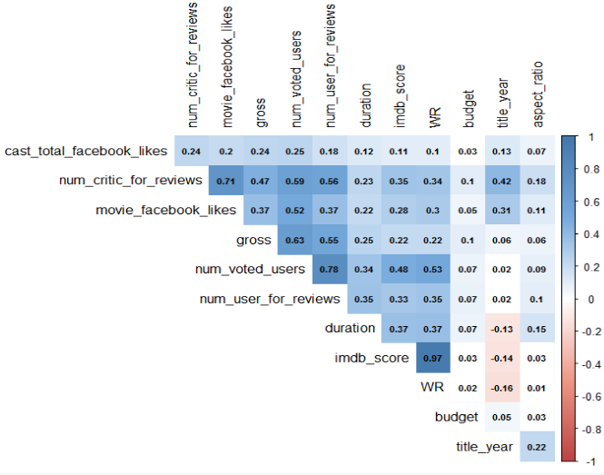

Foram inseridas todas as 22 novas variáveis provenientes dos gêneros sem duplicidade que foram descobertos na sessão anterior.

```r
db2 = as_tibble(cbind(as.data.frame(db1),fe))
set.seed(123851)
amostra3 = sample(x = 1:dim(db2)[1], size = 35, replace = FALSE)
db1[amostra3,] %>%
datatable(rownames = amostra3,options = list(searchin = TRUE, scrollX = TRUE, pageLength = 5))
```

| color | director_name | num_critic_for_reviews | duration | gross | genres | movie_title | num_voted_users | cast_total_facebook_likes | plot_keywords | movie_imdb_link | num_user_for_reviews | language | country | content_rating | budget | title_year | imdb_score | aspect_ratio | movie_facebook_likes | WR |
| --- | --- | --- | --- | --- | --- | --- | --- | --- | --- | --- | --- | --- | --- | --- | --- | --- | --- | --- | --- | --- |
| Color | Wes Craven | 256 | 101 | 26505000 | Horror | A Nightmare on Elm StreetÂ | 149285 | 42918 | freddy krueger\|lucid dream\|serial killer\|slasher\|sleep deprivation | http://www.imdb.com/title/tt0087800/?ref_=fn_tt_tt_1 | 668 | English | USA | X | 1800000 | 1984 | 7.5 | 1.85 | 10000 | 7.45521003295262 |
| Color | Richard Eyre | 220 | 92 | 17508670 | Crime\|Drama\|Romance\|Thriller | Notes on a ScandalÂ | 64625 | 646 | age difference\|school\|student\|teacher\|writing | http://www.imdb.com/title/tt0465551/?ref_=fn_tt_tt_1 | 281 | English | UK | R | 15000000 | 2006 | 7.4 | 1.85 | 0 | 7.31204188481675 |
| Color | Joe Johnston | 198 | 92 | 181166115 | Action\|Adventure\|Sci-Fi\|Thriller | Jurassic Park IIIÂ | 219501 | 2574 | dinosaur\|island\|jurassic park\|paleontologist\|search | http://www.imdb.com/title/tt0163025/?ref_=fn_tt_tt_1 | 1236 | English | USA | PG-13 | 93000000 | 2001 | 5.9 | 1.85 | 0 | 5.91854296449022 |
| Color | Joe Roth | 142 | 102 | 93607673 | Comedy\|Romance | America's SweetheartsÂ | 47573 | 9176 | actor\|love\|movie star\|press\|publicist | http://www.imdb.com/title/tt0265029/?ref_=fn_tt_tt_1 | 343 | English | USA | PG-13 | 48000000 | 2001 | 5.7 | 2.35 | 881 | 5.80261484616935 |
| Color | Peter Jackson | 297 | 171 | 313837577 | Action\|Adventure\|Drama\|Fantasy | The Lord of the Rings: The Fellowship of the RingÂ | 1238746 | 22342 | elf\|hobbit\|middle earth\|quest\|ring | http://www.imdb.com/title/tt0120737/?ref_=fn_tt_tt_1 | 5060 | English | New Zealand | PG-13 | 93000000 | 2001 | 8.8 | 2.35 | 21000 | 8.7870760171014 |
| Color | Gary Sherman | 66 | 98 | 14114488 | Horror\|Thriller | Poltergeist IIIÂ | 13190 | 3827 | aunt niece relationship\|brother sister relationship\|building\|father daughter relationship\|mirror | http://www.imdb.com/title/tt0095889/?ref_=fn_tt_tt_1 | 114 | English | USA | PG-13 | 10500000 | 1988 | 4.5 | 1.85 | 616 | 5.19341258048539 |
| Color | John G. Avildsen | 81 | 126 | 90800000 | Action\|Drama\|Family\|Sport | The Karate KidÂ | 126916 | 2004 | apartment\|bully\|fight\|karate\|master | http://www.imdb.com/title/tt0087538/?ref_=fn_tt_tt_1 | 235 | English | USA | PG | 8000000 | 1984 | 7.2 | 1.85 | 0 | 7.1634098987425 |
| Color | Gonzalo LÃ³pez-Gallego | 228 | 86 | 17683670 | Horror\|Mystery\|Sci-Fi\|Thriller | Apollo 18Â | 47227 | 1520 | cosmonaut\|footprint\|found footage\|moon\|secret mission | http://www.imdb.com/title/tt1772240/?ref_=fn_tt_tt_1 | 323 | English | USA | PG-13 | 5000000 | 2011 | 5.2 | 1.33 | 0 | 5.367813082044 |
| Color | Robert Harmon | 81 | 89 | 12693621 | Horror\|Mystery\|Thriller | TheyÂ | 10885 | 4060 | darkness\|friend\|kiss\|nightmare\|suicide | http://www.imdb.com/title/tt0283632/?ref_=fn_tt_tt_1 | 271 | English | USA | PG-13 | 17000000 | 2002 | 4.8 | 2.35 | 814 | 5.46536203522505 |
| Color | Griffin Dunne | 92 | 104 | 46611204 | Comedy\|Drama\|Fantasy\|Romance | Practical MagicÂ | 55749 | 4294 | curse\|death\|island\|love\|magic | http://www.imdb.com/title/tt0120791/?ref_=fn_tt_tt_1 | 257 | English | USA | PG-13 | 48000000 | 1998 | 6.1 | 2.35 | 0 | 6.14462222505538 |

[output cut: 25 more lines]

# 4 Modelagem

## 4.1 Preparação de dados

Remove algumas variáveis como *plot_keywords, movie_imdb_link e imdb_score, genres* e transforma todas as variáveis em numéricas.

```r
movie <- db2
movie$color <- as.numeric(movie$color)
movie$director_name <- as.numeric(movie$director_name)
movie$genres <- as.numeric(movie$genres)
```

```r
movie$plot_keywords <- NULL
movie$movie_imdb_link <- NULL
movie$language <- as.numeric(movie$language)
movie$country <- as.numeric(movie$country)
movie$content_rating <- as.numeric(movie$content_rating)
movie$imdb_score <- NULL
movie$Sci_Fi <- movie$`Sci-Fi`
movie$Film_Noir <- movie$`Film-Noir`
movie$`Sci-Fi`<- NULL
movie$`Film-Noir` <- NULL
movie$genres <- NULL
```

Além disso, remove algum NA, se ainda houver.

```r
movie[is.na(movie)] <- 0
glimpse(movie)
```

```
## Observations: 3,766
## Variables: 39
## $ color                     <dbl> 0, 0, 0, 0, 0, 0, 0, 0, 0, 0, 0, 0, ...
## $ director_name             <dbl> 0, 0, 0, 0, 0, 0, 0, 0, 0, 0, 0, 0, ...
## $ num_critic_for_reviews    <dbl> 723, 302, 602, 813, 462, 392, 324, 6...
## $ duration                  <dbl> 178, 169, 148, 164, 132, 156, 100, 1...
## $ gross                     <dbl> 760505847, 309404152, 200074175, 448...
## $ movie_title               <chr> "AvatarÂ ", "Pirates of the Caribbea...
## $ num_voted_users           <dbl> 886204, 471220, 275868, 1144337, 212...
## $ cast_total_facebook_likes <dbl> 4834, 48350, 11700, 106759, 1873, 46...
## $ num_user_for_reviews      <dbl> 3054, 1238, 994, 2701, 738, 1902, 38...
## $ language                  <dbl> 0, 0, 0, 0, 0, 0, 0, 0, 0, 0, 0, 0, ...
## $ country                   <dbl> 0, 0, 0, 0, 0, 0, 0, 0, 0, 0, 0, 0, ...
## $ content_rating            <dbl> 0, 0, 0, 0, 0, 0, 0, 0, 0, 0, 0, 0, ...
## $ budget                    <dbl> 237000000, 300000000, 245000000, 250...
```

[output cut: 26 more lines]

[output not shown]

Também removemos os rótulos dos filmes

```r
movie$movie_title <- NULL # We are not going to work here with text variables
```

## 4.2 Random Forest

```r
#library(randomForest)
#library(rpart)
#library(rpart.plot)
rf <- randomForest(proximity = T,ntree = 38,do.trace = T,WR~.,data=training)
```

```
##      |      Out-of-bag   |
## Tree |      MSE  %Var(y) |
##    1 |   0.5804    80.70 |
##    2 |   0.5796    80.59 |
##    3 |   0.5379    74.78 |
##    4 |   0.5147    71.57 |
##    5 |   0.4954    68.88 |
##    6 |   0.4801    66.75 |
##    7 |   0.4687    65.17 |
##    8 |    0.459    63.82 |
##    9 |    0.448    62.29 |
##   10 |    0.444    61.73 |
##   11 |    0.419    58.25 |
##   12 |    0.409    56.86 |
##   13 |   0.3914    54.41 |
```

[output cut: 25 more lines]

```r
RF_importance = randomForest::importance(rf)[order(randomForest::importance(rf)[,1], decreasing = TRUE), ]
knitr::kable(RF_importance)
```

|  | x |
| --- | --- |
| num_user_for_reviews | 272.237155 |
| movie_facebook_likes | 216.816930 |
| duration | 197.025553 |
| num_critic_for_reviews | 193.457277 |
| title_year | 187.078698 |
| budget | 153.174220 |
| gross | 148.873436 |
| Drama | 110.441629 |
| cast_total_facebook_likes | 105.321855 |
| Horror | 40.891823 |
| aspect_ratio | 19.309461 |
| Animation | 18.669018 |
| Action | 18.369083 |
| Comedy | 16.451449 |
| Sci_Fi | 16.147963 |
| Fantasy | 13.894099 |
| Thriller | 13.868388 |
| Adventure | 12.669928 |
| Biography | 11.937412 |
| Crime | 11.255232 |
| Family | 9.734755 |
| Romance | 9.435029 |
| Music | 8.904362 |
| Documentary | 8.052032 |
| Mystery | 7.914024 |
| Sport | 7.205832 |
| Musical | 3.626385 |
| History | 3.000519 |
| War | 2.583427 |
| Western | 1.093158 |
| color | 0.000000 |
| director_name | 0.000000 |
| language | 0.000000 |
| country | 0.000000 |
| content_rating | 0.000000 |
| Film_Noir | 0.000000 |

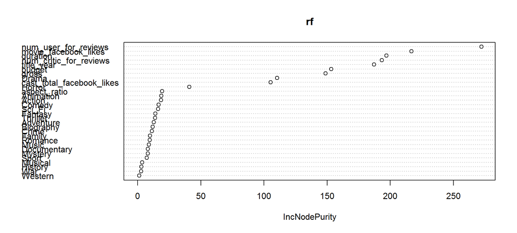

```r
randomForest::varImpPlot(rf)
```

No passo a seguir, removeremos as variáveis *color*, *director_name*, *language*, *country*, *content_rating* e *Film_Noir* uma vez que estas variáveis não se mostraram fatores importantes no algoritmo.

```r
movie = movie %>% select(-color, -director_name, -language, -country, -content_rating, -Film_Noir)
```

Assim, repetimos o algoritmo do Random Forest.

```r
rf <- randomForest(proximity = T,ntree = 32,do.trace = T,WR~.,data=movie)
```

```
##      |      Out-of-bag   |
## Tree |      MSE  %Var(y) |
##    1 |   0.5038    69.33 |
##    2 |    0.456    62.76 |
##    3 |   0.4525    62.28 |
##    4 |   0.4255    58.56 |
##    5 |   0.4132    56.87 |
##    6 |    0.389    53.53 |
##    7 |   0.3665    50.44 |
##    8 |    0.345    47.48 |
##    9 |   0.3317    45.65 |
##   10 |   0.3257    44.82 |
##   11 |   0.3171    43.64 |
##   12 |   0.3103    42.71 |
##   13 |   0.3058    42.08 |
```

[output cut: 19 more lines]

```r
RF_importance = randomForest::importance(rf)[order(randomForest::importance(rf)[,1], decreasing = TRUE), ]
class(data.frame(RF_importance))
```

```
## [1] "data.frame"
```

```r
hc3 <- highchart() %>%
  hc_add_series(data = RF_importance,
                type = "bar",
                name = "Importância no algoritmo",
                showInLegend = FALSE,
                tooltip = list(valueDecimals = 0, valuePrefix = "", valueSuffix = "")) %>%
  hc_yAxis(title = list(text = "Fatores"),
           allowDecimals = TRUE, max = (800),
           labels = list(format = "{value}")) %>%
  hc_xAxis(title = list(text = "Importância"),
           categories = names(RF_importance),
           tickmarkPlacement = "on",
           opposite = FALSE) %>%
  hc_title(text = "Importância por fator - Random Forest",
           style = list(fontWeight = "bold")) %>%
  hc_subtitle(text = paste("")) %>%
      hc_tooltip(valueDecimals = 2,
                 pointFormat = "{point.y} filmes")%>%
                 #pointFormat = "Variável: {point.x} <br> Missing: {point.y}")
      hc_credits(enabled = TRUE,
                 text = "Fonte: IMDB/KAGGLE. Elaboração: Ewerson Pimenta.",
                 style = list(fontSize = "10px")) %>%
  hc_exporting(enabled = TRUE, filename = "F3-filmes-genero-Pimenta")
#hc <- hc %>%
#  hc_add_theme(hc_theme_darkunica())
hc3
```

[output not shown]

[interactive chart not shown]

```r
RF = as_tibble(data.frame(variables = names(RF_importance), importance = RF_importance))
rownames(RF) <- NULL

hc4 <- highchart() %>%
  hc_add_series(data = RF$importance,
                type = "bar",
                name = "Importância",
                showInLegend = FALSE,
                tooltip = list(valueDecimals = 2, valuePrefix = "", valueSuffix = "")) %>%
  hc_yAxis(title = list(text = "Porcentagem de missing"),
           allowDecimals = TRUE, max = 800,
           labels = list(format = "{value}")) %>%
  hc_xAxis(title = list(text = "Fatores"),
           categories = RF$variables,
           tickmarkPlacement = "on",
           opposite = FALSE) %>%
  hc_title(text = "Importância por fator - Random Forest",
           style = list(fontWeight = "bold")) %>%
  hc_subtitle(text = paste("")) %>%
      hc_tooltip(valueDecimals = 2,
                 pointFormat = "Importância: {point.y}")%>%
                 #pointFormat = "Variável: {point.x} <br> Importância: {point.y}")
      hc_credits(enabled = TRUE,
                 text = "Fonte: IMDB/KAGGLE. Elaboração: Ewerson Pimenta.",
                 style = list(fontSize = "10px")) %>%
  hc_exporting(enabled = TRUE, filename = "F4-missing-Pimenta")
#hc <- hc %>%
#  hc_add_theme(hc_theme_darkunica())
hc4
```

[interactive chart not shown]

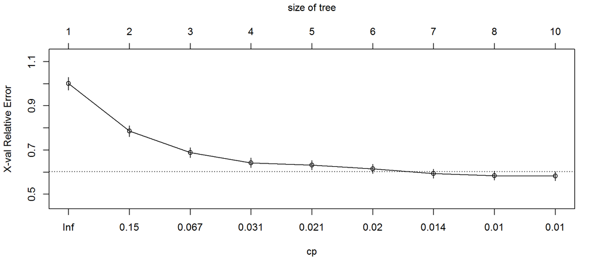

```r
rp <- rpart::rpart(formula = WR~.,data=movie)
rpart::plotcp(rp)
```

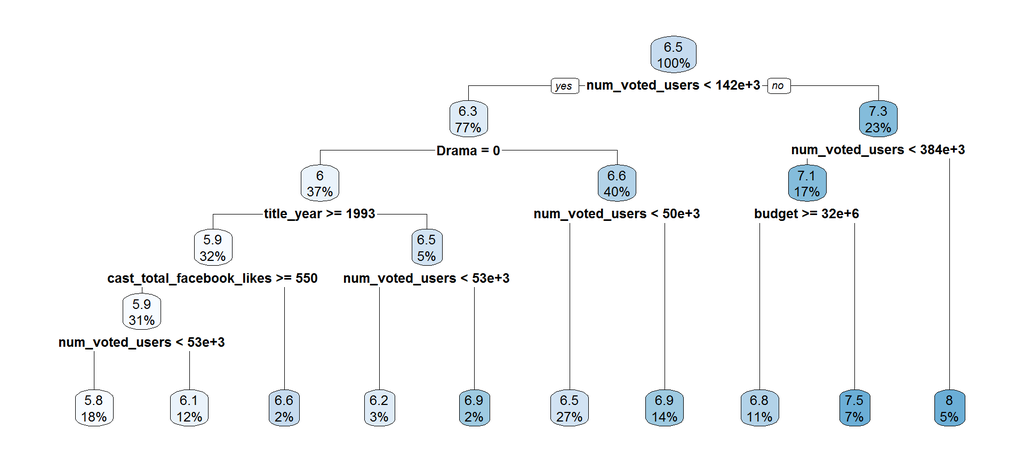

```r
rpart.plot(rp)
```